[figure not shown]

# Métodos Computacionais II

2018/2

[Jony Arrais Pinto Junior](http://lattes.cnpq.br/4940428746026448)

## 1 - Conteúdo Aula 14

- Teste de hipóteses para duas populações usando o R

## 2 - Teste de hipóteses para comparação de médias de duas populações normais independentes

O dono de uma fábrica, possui duas máquinas empacotando um determinado produto $K$. O dono da fábrica coletou a informação do peso de 25 pacotes prodduzidos pela máquina A e 20 pacotes produzidos pela máquina B. O produtor quer saber se as máquinas estão produzindo da mesma forma. Com base nos dados, qual a sua conclusão?

Hipótese:
$$H_0: \mu_A = \mu_B \qquad \times \qquad H_1: \mu_A \neq \mu_B,$$
ou equivalentemente,
$$H_0: \mu_A - \mu_B = 0 \qquad \times \qquad H_1: \mu_A - \mu_B \neq 0.$$

Dados:

```
## # A tibble: 6 x 3
##   Maquina  Peso Defeito
##   <chr>   <dbl>   <int>
## 1 A       107.        0
## 2 B       144.        0
## 3 A        97.8       1
## 4 B       137.        0
## 5 A       101.        0
## 6 A        94.5       0
```

### 2.1 - Verificando normalidade dos dados

Checando a normalidade:

```r
library(dplyr)
library(gridExtra)
```

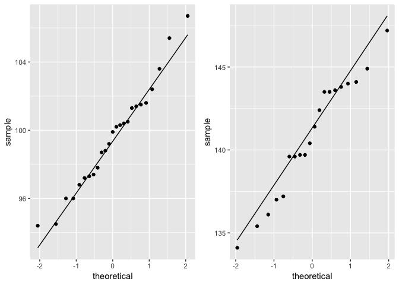

```r
library(ggplot2)
baseA = base %>% filter(Maquina == "A")
baseB = base %>% filter(Maquina == "B")


graf1 = baseA %>% ggplot(aes(sample = Peso)) + stat_qq() + stat_qq_line()
graf2 = baseB %>% ggplot(aes(sample = Peso)) + stat_qq() + stat_qq_line()

grid.arrange(graf1, graf2, ncol = 2)
```

```r
ks.test(baseA$Peso, "pnorm", mean(baseA$Peso), sd(baseA$Peso))
```

```
##
##  One-sample Kolmogorov-Smirnov test
##
## data:  baseA$Peso
## D = 0.096908, p-value = 0.973
## alternative hypothesis: two-sided
```

```r
ks.test(baseB$Peso, "pnorm", mean(baseB$Peso), sd(baseB$Peso))
```

```
##
##  One-sample Kolmogorov-Smirnov test
##
## data:  baseB$Peso
## D = 0.17019, p-value = 0.6085
## alternative hypothesis: two-sided
```

### Qual a sua conclusão?

### 2.2 - Verificando igualdade das variâncias

```r
library(DescTools)

var(baseA$Peso)
```

```
## [1] 9.647933
```

```r
var(baseB$Peso)
```

```
## [1] 12.74568
```

```r
VarTest(baseA$Peso, baseB$Peso, alternative = "two.sided", ratio = 1, conf.level = 0.95)
```

```
##
##  F test to compare two variances
##
## data:  x and y
## F = 0.75696, num df = 24, denom df = 19, p-value = 0.5137
## alternative hypothesis: true ratio of variances is not equal to 1
## 95 percent confidence interval:
##  0.3086696 1.7751803
## sample estimates:
## ratio of variances
##          0.7569569
```

### Qual a sua conclusão?

### 2.3 - Verificando igualdade das médias

```r
resultados = base %>% group_by(Maquina) %>% summarise(N = n(), media = mean(Peso), desvio.padrao = sd(Peso), LI = media - qt(p = 0.975, df = N-1)*desvio.padrao/sqrt(N), LS = media + qt(p = 0.975, df = N-1)*desvio.padrao/sqrt(N))

resultados
```

```
## # A tibble: 2 x 6
##   Maquina     N media desvio.padrao    LI    LS
##   <chr>   <int> <dbl>         <dbl> <dbl> <dbl>
## 1 A          25  99.6          3.11  98.3  101.
## 2 B          20 141.           3.57 139.   143.
```

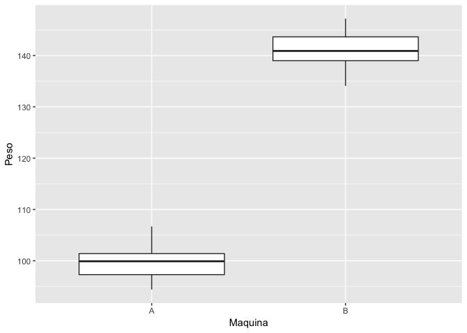

```r
library(ggplot2)

#Plotando o boxplot
ggplot(base, aes(y=Peso, x=Maquina)) + geom_boxplot()
```

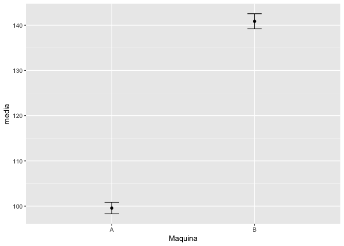

```r
#Plotando o gráfico de médias e intervalo de confiança

ggplot(resultados, aes(x=Maquina, y = media)) +
   #Desenha as médias
      geom_point() +
   #Desenha as barras do Intervalo de Confiança
      geom_errorbar(data=resultados, aes(ymin=LI, ymax=LS), width=.1)
```

```r
#Realizando o teste de médias

t.test(baseA$Peso, baseB$Peso, alternative = "two.sided", mu = 0, var.equal = TRUE, conf.level = 0.95)
```

```
##
##  Two Sample t-test
##
## data:  baseA$Peso and baseB$Peso
## t = -41.465, df = 43, p-value < 2.2e-16
## alternative hypothesis: true difference in means is not equal to 0
## 95 percent confidence interval:
##  -43.29611 -39.27989
## sample estimates:
## mean of x mean of y
##    99.572   140.860
```

### Qual a sua conclusão?

## 3 - Teste para igualdade de proporções

Suponha agora que o dono da fábrica, deseja saber se a proporção de itens defeituosos em cada máquina é igual. Como proceder?

Hipótese:
$$H_0: p_A = p_B \qquad \times \qquad H_1: p_A \neq p_B,$$
ou equivalentemente,
$$H_0: p_A - p_B = 0 \qquad \times \qquad H_1: p_A - p_B \neq 0.$$

```r
resultados2 = base %>% group_by(Maquina) %>% summarise(N = n(), favoraveis = sum(Defeito), proporcao = favoraveis/N)

resultados2
```

```
## # A tibble: 2 x 4
##   Maquina     N favoraveis proporcao
##   <chr>   <int>      <int>     <dbl>
## 1 A          25          7      0.28
## 2 B          20          6      0.3
```

```r
#Realizando o teste de igualdade de proporções

prop.test(c(resultados2$favoraveis[1],resultados2$favoraveis[2]), c(resultados2$N[1],resultados2$N[2]), alternative = "two.sided", conf.level = 0.95, correct = FALSE)
```

```
##
##  2-sample test for equality of proportions without continuity
##  correction
##
## data:  c(resultados2$favoraveis[1], resultados2$favoraveis[2]) out of c(resultados2$N[1], resultados2$N[2])
## X-squared = 0.021635, df = 1, p-value = 0.8831
## alternative hypothesis: two.sided
## 95 percent confidence interval:
##  -0.2870446  0.2470446
## sample estimates:
## prop 1 prop 2
##   0.28   0.30
```

### Qual a sua conclusão?

## 4 - Teste de hipóteses para comparação de médias de duas populações normais dependentes

Um médico está verificando a eficácia de uma medicação para diabetis. Ele mediu a glicemia de pacientes com diabetis antes do início do tratamento e após o tratamento com a medicação. Para que o medicamento seja eficientes, o médico espera que a glicemia dos pacientes tenha diminuído. Você diria que o medicamento é eficiente?

Hipótese:
$$H_0: \mu_1 = \mu_2 \qquad \times \qquad H_1: \mu_1 > \mu_2,$$
ou equivalentemente,
$$H_0: \mu_1 - \mu_2 = 0 \qquad \times \qquad H_1: \mu_1 - \mu_2 > 0.$$

Dados:

```
## Using ',' as decimal and '.' as grouping mark. Use read_delim() for more control.
```

```
## # A tibble: 30 x 2
##    Glicemia1 Glicemia2
##        <dbl>     <dbl>
##  1      384.      328.
##  2      393.      334.
##  3      402       324
##  4      388.      349.
##  5      404.      322.
##  6      398.      323.
##  7      387.      312.
##  8      397.      298.
##  9      389.      306.
## 10      410.      307.
## # ... with 20 more rows
```

Checando a normalidade:

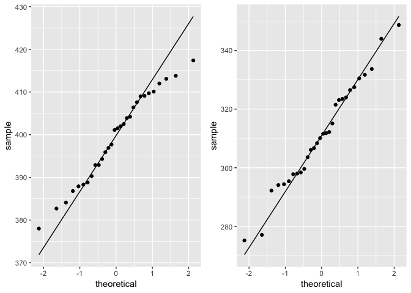

```r
graf3 = base2 %>% ggplot(aes(sample = Glicemia1)) + stat_qq() + stat_qq_line()
graf4 = base2 %>% ggplot(aes(sample = Glicemia2)) + stat_qq() + stat_qq_line()

grid.arrange(graf3, graf4, ncol = 2)
```

```r
ks.test(base2$Glicemia1, "pnorm", mean(base2$Glicemia1), sd(base2$Glicemia1))
```

```
##
##  One-sample Kolmogorov-Smirnov test
##
## data:  base2$Glicemia1
## D = 0.099193, p-value = 0.9294
## alternative hypothesis: two-sided
```

```r
ks.test(base2$Glicemia2, "pnorm", mean(base2$Glicemia2), sd(base2$Glicemia2))
```

```
##
##  One-sample Kolmogorov-Smirnov test
##
## data:  base2$Glicemia2
## D = 0.082525, p-value = 0.9763
## alternative hypothesis: two-sided
```

### Qual a sua conclusão?

```r
library(tidyr)

base.mod = base2 %>% gather(key = Tratamento, value = Glicemia, Glicemia1, Glicemia2)

head(base.mod)
```

```
## # A tibble: 6 x 2
##   Tratamento Glicemia
##   <chr>         <dbl>
## 1 Glicemia1      384.
## 2 Glicemia1      393.
## 3 Glicemia1      402
## 4 Glicemia1      388.
## 5 Glicemia1      404.
## 6 Glicemia1      398.
```

```r
resultados3 =   base.mod %>% group_by(Tratamento) %>% summarise(media = mean(Glicemia), desvio.padrao = sd(Glicemia), N = n())

resultados3
```

```
## # A tibble: 2 x 4
##   Tratamento media desvio.padrao     N
##   <chr>      <dbl>         <dbl> <int>
## 1 Glicemia1   399.          10.5    30
## 2 Glicemia2   311.          17.9    30
```

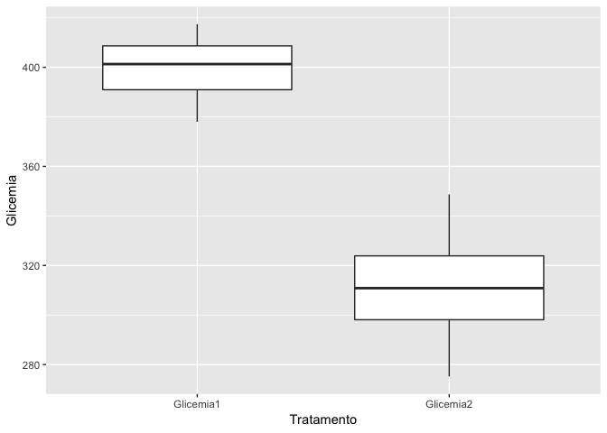

```r
#Plotando o boxplot
ggplot(base.mod, aes(y=Glicemia, x=Tratamento)) + geom_boxplot()
```

```r
#Realizando o teste de médias

t.test(base2$Glicemia1, base2$Glicemia2, alternative = "greater", mu = 0, paired = TRUE, conf.level = 0.95)
```

```
##
##  Paired t-test
##
## data:  base2$Glicemia1 and base2$Glicemia2
## t = 21.243, df = 29, p-value < 2.2e-16
## alternative hypothesis: true difference in means is greater than 0
## 95 percent confidence interval:
##  80.91215      Inf
## sample estimates:
## mean of the differences
##                87.94667
```

```r
dif = base2$Glicemia1 - base2$Glicemia2

t.test(dif, alternative = "greater", mu = 0, conf.level = 0.95)
```

```
##
##  One Sample t-test
##
## data:  dif
## t = 21.243, df = 29, p-value < 2.2e-16
## alternative hypothesis: true mean is greater than 0
## 95 percent confidence interval:
##  80.91215      Inf
## sample estimates:
## mean of x
##  87.94667
```